```python
import numpy as np, matplotlib.pyplot as plt, librosa as lr
import scipy as sc
from IPython.display import Audio
```

```python
!curl https://cdn.freesound.org/previews/94/94812_29541-lq.mp3 -o piano-scale.mp3
```

```
  % Total    % Received % Xferd  Average Speed   Time    Time     Time  Current
                                 Dload  Upload   Total   Spent    Left  Speed
100 78792  100 78792    0     0   216k      0 --:--:-- --:--:-- --:--:--  218k
```

# STFT - Visualisierung & Vertiefung

## Zu analysierende Audio-Files/-Signale

### Audio-Files Laden

Ladet folgende Audio-Files als np-Array:

- `amen-break.wav`
- `piano-scale.wav`

#### `amen-break.wav` mit `scipy` laden

```python
sr_amen, y_amen = sc.io.wavfile.read('amen-break.wav')

print(f'min:\t{np.min(y_amen)}\nmax:\t{np.max(y_amen)}\ntype:\t{y_amen.dtype}\n\n{y_amen}')
```

```
min:	-28207
max:	32767
type:	int16

[[   3    3]
 [ 694  694]
 [-284 -284]
 ...
 [-603 -603]
 [-276 -276]
 [   0    0]]
```

Die `.read`-Methode von Scipy lädt die Wav-File als Integer.

Geben wir uns ein paar Informationen über den geladenen Array aus (siehe oben), erfahren wir, dass der Datentyp ein 16-bit Integer ist und sowohl negative, als auch positive Werte annimmt.

```python
2 ** 15
```

```
32768
```

```python
2 ** 15 // 2
```

```
16384
```

```python
y_amen_scaled = y_amen / (2 ** 15)

print(f'max:\t{np.max(y_amen_scaled)}\nmin:\t{np.min(y_amen_scaled)}')
```

```
max:	0.999969482421875
min:	-0.860809326171875
```

```python
y_amen_scaled = y_amen_scaled.T # da der Array wie "interlaced"
                                # geladen wird, und wir die Arrays
                                # der channels hintereinander benötigen,
                                # wenden wir die Transformierte an
```

```python
display(Audio(y_amen_scaled, rate=sr_amen))
```

[interactive chart not shown]

#### `piano-scale` mit `lr.load` laden

```python
y_piano, sr_piano = lr.load('piano-scale.mp3')
display(Audio(y_piano, rate=sr_piano))
```

[interactive chart not shown]

### Custom Audio Signal:

Erstellt ein Audio-Signal:

- mit einer Sample-Rate von 8000 Hz
- mit der Länge von 1 Sek.
- mit zwei Sinus-Signalen mit
  - den Frequenzen 500 und 540 Hz
  - Amplituden jeweils 0.125
- mit zwei Dirac-Impulsen (einfach den Wert eines Samples im Signal auf $1$ setzen) an den Index-Stellen $3920$ und $4080$

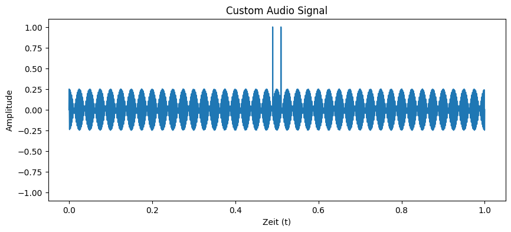

[interactive chart not shown]

```python
sr = 8000
length = 1
freqs = [500, 540]
amp = 0.125
y_custom = np.zeros(int(sr * length))

t = np.arange(int(length * sr)) / sr

for freq in freqs:
    y_custom = y_custom + np.sin(2 * np.pi * length * freq * t) * amp

##############################
# alternative
freq1, freq2 = 500, 540
amp1, amp2 = 0.125, 0.125

t = np.linspace(0, length, num=int(sr * length))
sinusoid1 = np.sin(2 * np.pi * freq1 * t) * amp1
sinusoid2 = np.sin(2 * np.pi * freq2 * t) * amp2
y_custom = sinusoid1 + sinusoid2
###############################

# Dirac-Impulse
y_custom[3920] = 1
y_custom[4080] = 1

# Plotten
plt.figure(figsize=(10, 4))
plt.plot(t, y_custom)
plt.title('Custom Audio Signal')
plt.xlabel('Zeit (t)')
plt.ylabel('Amplitude')
plt.ylim(-1.1, 1.1)
plt.show()

display(Audio(y_custom, rate=sr))
```

## Visualisierung der STFT

### STFT Berechnung

Berechnet die STFT aller drei Signale mit der Funktion `lr.stft` mit den Default-Parametern.

```python
stft_amen = lr.stft(y_amen_scaled)
stft_piano = lr.stft(y_piano)
stft_custom = lr.stft(y_custom)
```

### STFT visualisieren mit `lr.display.specshow`

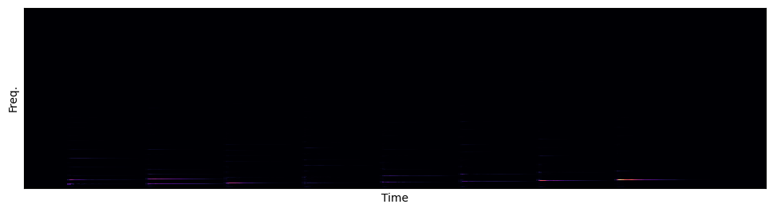

```python
# ... hier werden wir nächste Woche fortfahren ...

plt.figure(figsize=(12, 10))

plt.subplot(3, 1, 1)
lr.display.specshow(np.abs(stft_piano)) # Magnitude <=> Absoluter Wert
plt.ylabel('Freq.')
plt.xlabel('Time')

plt.show()
```

### STFT visualisieren mit `plt.imshow`

### Logarithmus-Gamma-Kompression

Die Log-Gamma-Kompression ist eine Technik zur Verbesserung des Dynamikbereichs eines Signals zur einfacheren Darstellung, insbesondere bei Visualisierungen wie Spektrogrammen.

Dabei wird die Dynamik-Skala der menschlichen Wahrnehmung angepasst, mittels folgender Formel: $$y_{\text{compressed}} = \log{\left(1 + \gamma \cdot y \right)}$$ wobei der Gamma-Wert ($\gamma$) ein Parameter ist, den wir nach Bedarf ändern können. Je höher der Wert, desto stärker die Kompression, wodurch leise Teile des Signals hervorgehoben werden.

## Parameter einstellen

Variiert verschiedene Parameter der STFTs der drei Signale:

- `win_length`
- `hop_length`
- `window` (siehe auch: [A_list_of_window_functions - Wikipedia](https://en.wikipedia.org/wiki/Window_function#A_list_of_window_functions))

### Parameter einstellen für Amen-Break

### Parameter einstellen für das Melodische Sample

### Parameter einstellen für das eigens kreierte Audio Signal